# Estudo Proagro

Vitor Villarino

03/09/2019

## Considerações

### Produto

Por enquanto apenas **SOJA**. No futuro teremos Milho.

### Severidade e Intensidade

A Severidade é o valor deferido dividido pelo valor enquadrado das operações deferidas, porém, como a base é agregada e não abre os seguros um a um, não temos os valores enquadrados das operações deferidas. Uma saída é pedir para que eles calculem e nos envie o agregado.

### SAFRA

Ainda há poucos seguros para a safra 2019/2020. Com a nossa regra de 30 seguros por safra (mínimo), vários municípios estavam ficando de fora. Retirei das análises essa safra para não atrapalhar

|  | 2013/2014 | 2014/2015 | 2015/2016 | 2016/2017 | 2017/2018 | 2018/2019 | 2019/2020 | Total |
| --- | --- | --- | --- | --- | --- | --- | --- | --- |
| PRONAF | 105211 | 110330 | 110868 | 101379 | 99977 | 88130 | 20062 | 635957 |
| PRONAMP | 9940 | 9181 | 7272 | 7686 | 7782 | 8160 | 1853 | 51874 |
| SEM PROGRAMA | 2563 | 2563 | 2250 | 2710 | 2375 | 1537 | 195 | 14193 |
| Total | 117714 | 122074 | 120390 | 111775 | 110134 | 97827 | 22110 | 702024 |

### Programas

A distribuição do número de Seguros por Programa mostra que há poucos seguros dos programas PRONAMP e SEM PROGRAMA no Proagro Mais e poucos seguros do PRONAF no PROAGRO TRADICIONAL. Retiraremos estes seguros “outliers”.

| **PROGRAMA** | TP_SEGURO PROAGRO MAIS | TP_SEGURO PROAGRO MAIS | TP_SEGURO PROAGRO MAIS | TP_SEGURO PROAGRO MAIS | TP_SEGURO PROAGRO <br/>TRADICIONAL | TP_SEGURO PROAGRO <br/>TRADICIONAL | TP_SEGURO PROAGRO <br/>TRADICIONAL | TP_SEGURO PROAGRO <br/>TRADICIONAL | Total | Total | Total | Total |
| --- | --- | --- | --- | --- | --- | --- | --- | --- | --- | --- | --- | --- |
| **PRONAF** | 615436.0 | ( | 99.9% | ) | 459.0 | ( | 0.1% | ) | 615895.0 | ( | 100.0% | ) |
| **PRONAMP** | 11.0 | ( | 0.0% | ) | 50010.0 | ( | 100.0% | ) | 50021.0 | ( | 100.0% | ) |
| **SEM PROGRAMA** | 7.0 | ( | 0.1% | ) | 13991.0 | ( | 99.9% | ) | 13998.0 | ( | 100.0% | ) |
| **Total** | 615454.0 | ( | 90.5% | ) | 64460.0 | ( | 9.5% | ) | 679914.0 | ( | 100.0% | ) |

### Inflação

Usei os valores do IPCA acumulado de 12 meses (julho a julho). Peguei do site do IBGE https://ww2.ibge.gov.br/home/estatistica/indicadores/precos/inpc_ipca/defaultseriesHist.shtm e no final obtive os seguintes valores:

| jul2014 | jul2015 | jul2016 | jul2017 | jul2018 | jul2019 |
| --- | --- | --- | --- | --- | --- |
| 6.5 | 9.56 | 8.74 | 2.71 | 4.48 | 3.22 |

Se compararmos os valores deflacionados antes e depois temos uma boa melhora, porém, como o valor máximo do Proagro não foi atualizado, perdemos aquele máximo de R$ 300.000.

Valores antes de deflacionar:

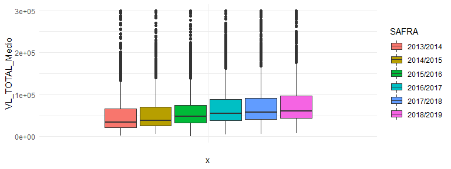

|  | 2013/2014 | 2014/2015 | 2015/2016 | 2016/2017 | 2017/2018 | 2018/2019 |
| --- | --- | --- | --- | --- | --- | --- |
| **Média** | 55466.00 | 59401.32 | 64589.79 | 73880.28 | 76844.58 | 80415.94 |
| **Desv.padrão** | 55812.65 | 55665.95 | 52701.00 | 54178.15 | 56168.03 | 56792.14 |
| **Mín** | 2453.88 | 5490.65 | 118.43 | 4016.00 | 6336.00 | 6998.99 |
| **Med** | 34182.07 | 38233.50 | 47384.26 | 55355.14 | 57395.39 | 60315.70 |
| **Máx** | 300000.00 | 300000.00 | 300000.00 | 300000.00 | 300000.00 | 300000.00 |

Valores depois de deflacionar:

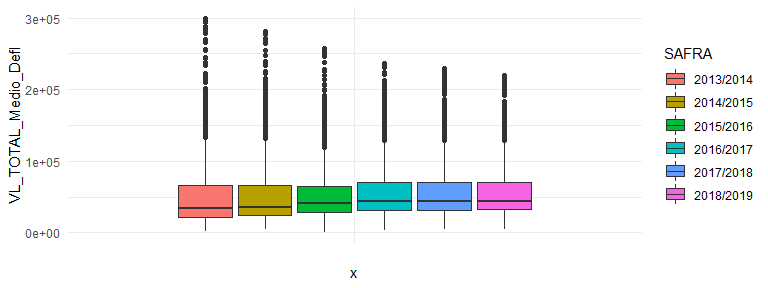

|  | 2013/2014 | 2014/2015 | 2015/2016 | 2016/2017 | 2017/2018 | 2018/2019 |
| --- | --- | --- | --- | --- | --- | --- |
| **Média** | 55466.00 | 55775.88 | 55355.68 | 58228.76 | 58967.07 | 59061.61 |
| **Desv.padrão** | 55812.65 | 52268.50 | 45166.58 | 42700.52 | 43100.82 | 41711.07 |
| **Mín** | 2453.88 | 5155.54 | 101.50 | 3165.21 | 4861.96 | 5140.42 |
| **Med** | 34182.07 | 35900.00 | 40609.95 | 43628.17 | 44042.64 | 44298.96 |
| **Máx** | 300000.00 | 281690.14 | 257110.39 | 236445.09 | 230206.49 | 220335.46 |

### Municípios

Distribuição por Estado

**Grupo**: "Sigla_UF" = Sigla_UF

| Sigla_UF | Freq | % | % Acum. |
| --- | --- | --- | --- |
| AP | 1 | 0.05 | 0.05 |
| BA | 11 | 0.60 | 0.65 |
| DF | 1 | 0.05 | 0.71 |
| GO | 135 | 7.36 | 8.07 |
| MA | 38 | 2.07 | 10.14 |
| MG | 140 | 7.63 | 17.77 |
| MS | 68 | 3.71 | 21.47 |
| MT | 84 | 4.58 | 26.05 |
| PA | 21 | 1.14 | 27.19 |
| PI | 11 | 0.60 | 27.79 |
| PR | 372 | 20.27 | 48.07 |
| RO | 20 | 1.09 | 49.16 |
| RR | 5 | 0.27 | 49.43 |
| RS | 424 | 23.11 | 72.53 |
| SC | 192 | 10.46 | 83.00 |
| SP | 250 | 13.62 | 96.62 |
| TO | 62 | 3.38 | 100.00 |
| Total | 1835 | 100.00 | 100.00 |

Distribuição do número de seguros nesses estados

Distribuição dos Seguros por Estado

|  | 2013/2014 | 2014/2015 | 2015/2016 | 2016/2017 | 2017/2018 | 2018/2019 | Total |
| --- | --- | --- | --- | --- | --- | --- | --- |
| AP | 0 | 0 | 0 | 0 | 1 | 1 | 2 |
| BA | 17 | 26 | 12 | 17 | 18 | 21 | 111 |
| DF | 15 | 11 | 5 | 2 | 3 | 1 | 37 |
| GO | 745 | 684 | 524 | 486 | 459 | 377 | 3275 |
| MA | 40 | 56 | 46 | 26 | 51 | 42 | 261 |
| MG | 240 | 300 | 239 | 255 | 210 | 243 | 1487 |
| MS | 1664 | 1728 | 1677 | 1523 | 1445 | 1237 | 9274 |
| MT | 517 | 553 | 484 | 444 | 422 | 270 | 2690 |
| PA | 45 | 34 | 67 | 107 | 84 | 80 | 417 |
| PI | 16 | 20 | 15 | 8 | 5 | 6 | 70 |
| PR | 40080 | 42040 | 41941 | 40167 | 39628 | 34270 | 238126 |
| RO | 45 | 48 | 43 | 87 | 56 | 32 | 311 |
| RR | 0 | 0 | 8 | 7 | 5 | 10 | 30 |
| RS | 66666 | 68133 | 66254 | 61371 | 60539 | 54824 | 377787 |
| SC | 6365 | 7265 | 8037 | 6268 | 6384 | 5746 | 40065 |
| SP | 938 | 946 | 932 | 848 | 756 | 619 | 5039 |
| TO | 110 | 105 | 58 | 66 | 68 | 48 | 455 |
| Total | 117503 | 121949 | 120342 | 111682 | 110134 | 97827 | 679437 |

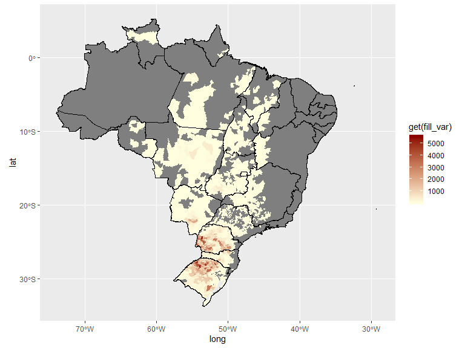

## Análise

### Valor Enquadrado Médio por Área

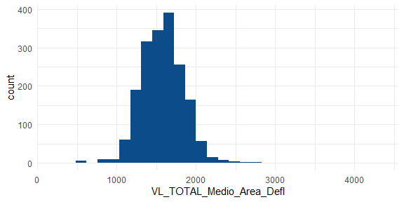

|  | VL_TOTAL_ Medio_Area_ Defl |
| --- | --- |
| **Média** | 1577.76 |
| **Desv.padrão** | 277.61 |
| **Mín** | 235.28 |
| **Q1** | 1394.76 |
| **Med** | 1581.50 |
| **Q3** | 1745.21 |
| **Máx** | 4239.68 |
| **MDA** | 258.73 |
| **IQE** | 350.42 |

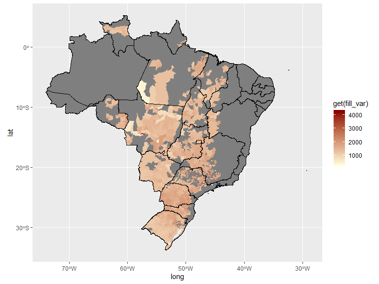

Para estes dois municípios acredito que tenha havido algum tipo de erro. Em uma das safras Constantina teve uma área total mais de 10x maior que a dos outros anos e em Aratiba 15x. A área muito grande interfere na média geral e joga lá para baixo o preço por área. Acredito que seja melhor tirar estes dois municípios.

Seguros Constantina

| SAFRA | PROGRAMA | TP_SEGURO | num_seguros | NR_AREA_TOTAL | VL_TOTAL_deflacionado | VL_TOTAL_Medio_Area_Defl |
| --- | --- | --- | --- | --- | --- | --- |
| 2013/2014 | PRONAF | PROAGRO MAIS | 618 | 6725.77 | 9670289.1 | 1437.7966 |
| 2013/2014 | PRONAMP | PROAGRO TRADICIONAL | 1 | 95.00 | 104500.0 | 1100.0000 |
| 2014/2015 | PRONAF | PROAGRO MAIS | 620 | 96217.77 | 10451162.2 | 108.6199 |
| 2014/2015 | PRONAMP | PROAGRO TRADICIONAL | 5 | 309.21 | 341452.1 | 1104.2725 |
| 2015/2016 | PRONAF | PROAGRO MAIS | 574 | 7475.83 | 14417748.9 | 1928.5817 |
| 2015/2016 | PRONAMP | PROAGRO TRADICIONAL | 6 | 314.40 | 357887.4 | 1138.3186 |
| 2016/2017 | PRONAF | PROAGRO MAIS | 521 | 6801.77 | 13115553.3 | 1928.2559 |
| 2016/2017 | PRONAMP | PROAGRO TRADICIONAL | 3 | 136.00 | 170409.7 | 1253.0126 |
| 2017/2018 | PRONAF | PROAGRO MAIS | 525 | 7293.02 | 14830071.5 | 2033.4610 |
| 2017/2018 | PRONAMP | PROAGRO TRADICIONAL | 9 | 413.73 | 538775.7 | 1302.2399 |
| 2018/2019 | PRONAF | PROAGRO MAIS | 459 | 6285.99 | 12456532.5 | 1981.6342 |
| 2018/2019 | PRONAMP | PROAGRO TRADICIONAL | 8 | 396.95 | 545516.7 | 1374.2706 |

Seguros Aratiba

| SAFRA | PROGRAMA | TP_SEGURO | num_seguros | NR_AREA_TOTAL | VL_TOTAL_deflacionado | VL_TOTAL_Medio_Area_Defl |
| --- | --- | --- | --- | --- | --- | --- |
| 2013/2014 | PRONAF | PROAGRO MAIS | 66 | 15863.37 | 939435.110 | 59.2204 |
| 2013/2014 | PRONAMP | PROAGRO TRADICIONAL | 3 | 64.00 | 66042.290 | 1031.9108 |
| 2014/2015 | PRONAF | PROAGRO MAIS | 83 | 748.84 | 1124541.568 | 1501.7114 |
| 2014/2015 | PRONAMP | PROAGRO TRADICIONAL | 3 | 51.00 | 62700.000 | 1229.4118 |
| 2014/2015 | SEM PROGRAMA | PROAGRO TRADICIONAL | 1 | 4.00 | 4541.634 | 1135.4085 |
| 2015/2016 | PRONAF | PROAGRO MAIS | 101 | 1020.89 | 2155697.386 | 2111.5863 |
| 2015/2016 | PRONAMP | PROAGRO TRADICIONAL | 4 | 60.00 | 74950.909 | 1249.1818 |
| 2016/2017 | PRONAF | PROAGRO MAIS | 60 | 754.50 | 1475844.190 | 1956.0559 |
| 2016/2017 | PRONAMP | PROAGRO TRADICIONAL | 1 | 25.00 | 35466.763 | 1418.6705 |
| 2016/2017 | SEM PROGRAMA | PROAGRO TRADICIONAL | 1 | 38.00 | 53864.910 | 1417.4976 |
| 2017/2018 | PRONAF | PROAGRO MAIS | 95 | 1089.04 | 2206886.729 | 2026.4515 |
| 2017/2018 | PRONAMP | PROAGRO TRADICIONAL | 3 | 57.00 | 83195.291 | 1459.5665 |
| 2018/2019 | PRONAF | PROAGRO MAIS | 86 | 993.50 | 2085195.004 | 2098.8374 |
| 2018/2019 | PRONAMP | PROAGRO TRADICIONAL | 2 | 95.00 | 129065.897 | 1358.5884 |

### Prêmio Médio por Área

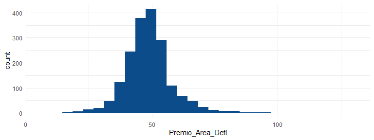

|  | Premio_Area_ Defl |
| --- | --- |
| **Média** | 49.03 |
| **Desv.padrão** | 10.05 |
| **Mín** | 7.06 |
| **Q1** | 43.48 |
| **Med** | 48.32 |
| **Q3** | 53.10 |
| **Máx** | 127.19 |
| **MDA** | 7.13 |
| **IQE** | 9.61 |

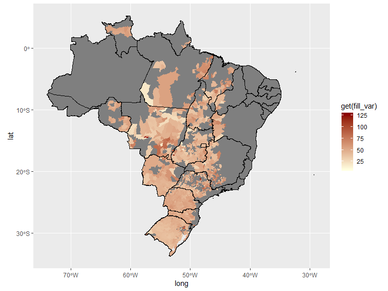

### Índice de Incidência Global (Qtd Sinistros/Qtd Total de Seguros)

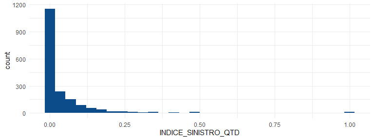

|  | INDICE_ SINISTRO_QTD |
| --- | --- |
| **Média** | 0.05 |
| **Desv.padrão** | 0.11 |
| **Mín** | 0.00 |
| **Q1** | 0.00 |
| **Med** | 0.00 |
| **Q3** | 0.05 |
| **Máx** | 1.00 |
| **MDA** | 0.00 |
| **IQE** | 0.05 |

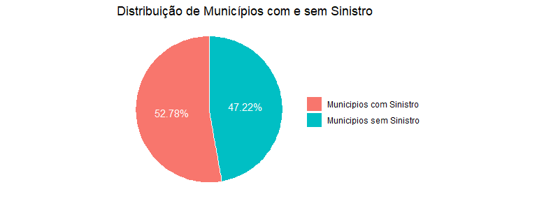

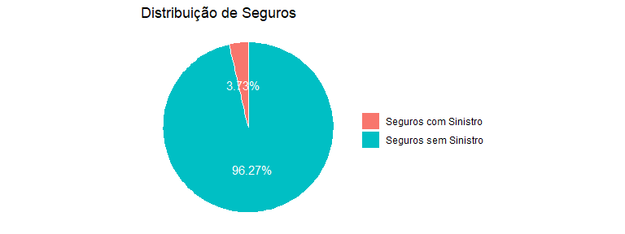

Se retirarmos os municipios que não tiveram 0, temos algo bem parecido.

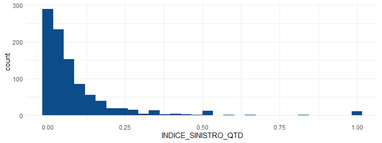

|  | INDICE_ SINISTRO_QTD |
| --- | --- |
| **Média** | 0.09 |
| **Desv.padrão** | 0.14 |
| **Mín** | 0.00 |
| **Q1** | 0.01 |
| **Med** | 0.04 |
| **Q3** | 0.10 |
| **Máx** | 1.00 |
| **MDA** | 0.05 |
| **IQE** | 0.09 |

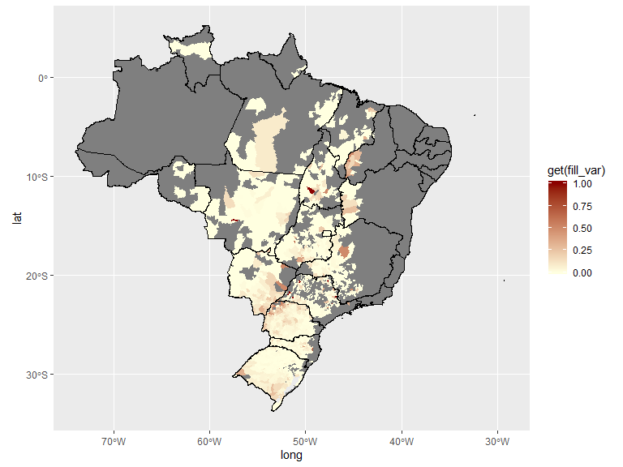

### Sinistro Médio

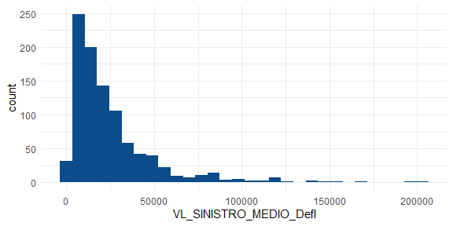

|  | VL_SINISTRO_ MEDIO_Defl |
| --- | --- |
| **Média** | 25779.97 |
| **Desv.padrão** | 26331.55 |
| **Mín** | 404.93 |
| **Q1** | 9698.02 |
| **Med** | 17602.32 |
| **Q3** | 31393.79 |
| **Máx** | 203341.38 |
| **MDA** | 13753.99 |
| **IQE** | 21691.64 |

Seguros Piratini

| SAFRA | PROGRAMA | num_seguros | NR_AREA_TOTAL | QT_SINISTROS | VL_SINISTRO_MEDIO_Defl |
| --- | --- | --- | --- | --- | --- |
| 2013/2014 | PRONAF | 47 | 1889.33 | 1 | 2631.20 |
| 2013/2014 | PRONAMP | 53 | 5598.92 | 0 | NaN |
| 2013/2014 | SEM PROGRAMA | 4 | 480.00 | 0 | NaN |
| 2014/2015 | PRONAF | 50 | 1991.23 | 1 | 15586.28 |
| 2014/2015 | PRONAMP | 44 | 5070.70 | 4 | 68582.05 |
| 2014/2015 | SEM PROGRAMA | 7 | 843.00 | 0 | NaN |
| 2015/2016 | PRONAF | 49 | 2149.40 | 15 | 49267.17 |
| 2015/2016 | PRONAMP | 49 | 5122.65 | 8 | 82460.25 |
| 2015/2016 | SEM PROGRAMA | 10 | 935.70 | 4 | 66448.44 |
| 2016/2017 | PRONAF | 42 | 1775.15 | 0 | NaN |
| 2016/2017 | PRONAMP | 41 | 4064.24 | 0 | NaN |
| 2016/2017 | SEM PROGRAMA | 10 | 1310.00 | 0 | NaN |
| 2017/2018 | PRONAF | 54 | 2252.56 | 18 | 47896.33 |
| 2017/2018 | PRONAMP | 44 | 4841.95 | 23 | 94525.50 |
| 2017/2018 | SEM PROGRAMA | 8 | 909.00 | 5 | 107568.83 |
| 2018/2019 | PRONAF | 52 | 1857.65 | 5 | 36454.64 |
| 2018/2019 | PRONAMP | 41 | 4483.30 | 2 | 79071.37 |
| 2018/2019 | SEM PROGRAMA | 5 | 702.30 | 0 | NaN |

### Índice de Sinistralidade

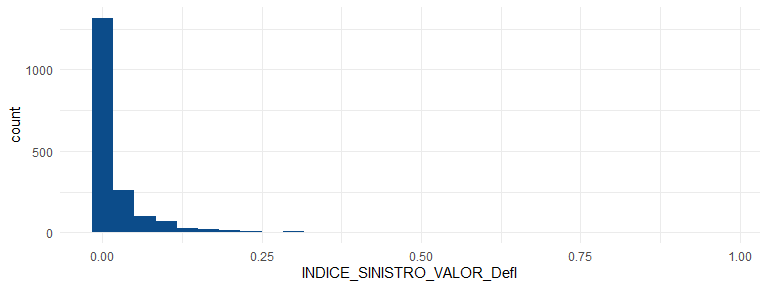

|  | INDICE_ SINISTRO_ VALOR_Defl |
| --- | --- |
| **Média** | 0.03 |
| **Desv.padrão** | 0.07 |
| **Mín** | 0.00 |
| **Q1** | 0.00 |
| **Med** | 0.00 |
| **Q3** | 0.02 |
| **Máx** | 0.97 |
| **MDA** | 0.00 |
| **IQE** | 0.02 |

Temos alguns valores acima de 15%. São eles: Diamante D’Oeste - PR, Japurá - PR e São Tomé - PR. Apesar dos Valores, não parece ter nada de errado.

Índice de Sinistralidade.

| Nome_Município | SAFRA | PROGRAMA | QT_SINISTROS | INDICE_SINISTRO_VALOR_Defl |
| --- | --- | --- | --- | --- |
| Alto Paraná | 2013/2014 | PRONAMP | 0 | 0.0000000 |
| Alto Paraná | 2013/2014 | SEM PROGRAMA | 0 | 0.0000000 |
| Alto Paraná | 2014/2015 | PRONAMP | 1 | 0.3390087 |
| Alto Paraná | 2014/2015 | SEM PROGRAMA | 1 | 0.6810013 |
| Alto Paraná | 2015/2016 | PRONAF | 2 | 0.6110540 |
| Alto Paraná | 2015/2016 | PRONAMP | 0 | 0.0000000 |
| Alto Paraná | 2015/2016 | SEM PROGRAMA | 0 | 0.0000000 |
| Alto Paraná | 2016/2017 | PRONAF | 1 | 0.2439317 |
| Alto Paraná | 2017/2018 | PRONAF | 0 | 0.0000000 |
| Alto Paraná | 2017/2018 | PRONAMP | 0 | 0.0000000 |
| Alto Paraná | 2017/2018 | SEM PROGRAMA | 1 | 0.2892364 |
| Alto Paraná | 2018/2019 | PRONAF | 0 | 0.0000000 |
| Alto Paraná | 2018/2019 | PRONAMP | 1 | 0.2225110 |
| Auriflama | 2015/2016 | PRONAF | 1 | 0.3540226 |
| Batayporã | 2013/2014 | PRONAF | 3 | 0.3204065 |
| Batayporã | 2013/2014 | PRONAMP | 6 | 0.4154733 |
| Batayporã | 2013/2014 | SEM PROGRAMA | 0 | 0.0000000 |
| Batayporã | 2014/2015 | PRONAF | 2 | 0.1399546 |
| Batayporã | 2014/2015 | PRONAMP | 3 | 0.2292989 |
| Batayporã | 2014/2015 | SEM PROGRAMA | 0 | 0.0000000 |
| Batayporã | 2015/2016 | PRONAF | 4 | 0.3851691 |
| Batayporã | 2015/2016 | PRONAMP | 2 | 0.5441769 |
| Batayporã | 2015/2016 | SEM PROGRAMA | 1 | 0.0860030 |
| Batayporã | 2016/2017 | PRONAF | 0 | 0.0000000 |
| Batayporã | 2016/2017 | SEM PROGRAMA | 0 | 0.0000000 |
| Batayporã | 2017/2018 | PRONAF | 0 | 0.0000000 |
| Batayporã | 2018/2019 | PRONAF | 0 | 0.0000000 |
| Batayporã | 2018/2019 | PRONAMP | 0 | 0.0000000 |
| Boituva | 2013/2014 | SEM PROGRAMA | 1 | 0.5736352 |
| Boituva | 2018/2019 | PRONAF | 0 | 0.0000000 |

[output cut: 382 more lines]

Se retirarmos os municipios que não tiveram 0, temos algo bem parecido.

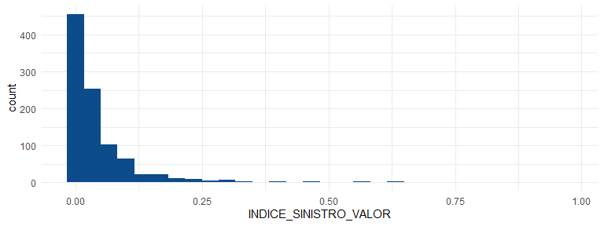

|  | INDICE_ SINISTRO_ VALOR |
| --- | --- |
| **Média** | 0.05 |
| **Desv.padrão** | 0.09 |
| **Mín** | 0.00 |
| **Q1** | 0.00 |
| **Med** | 0.02 |
| **Q3** | 0.05 |
| **Máx** | 0.97 |
| **MDA** | 0.03 |
| **IQE** | 0.05 |

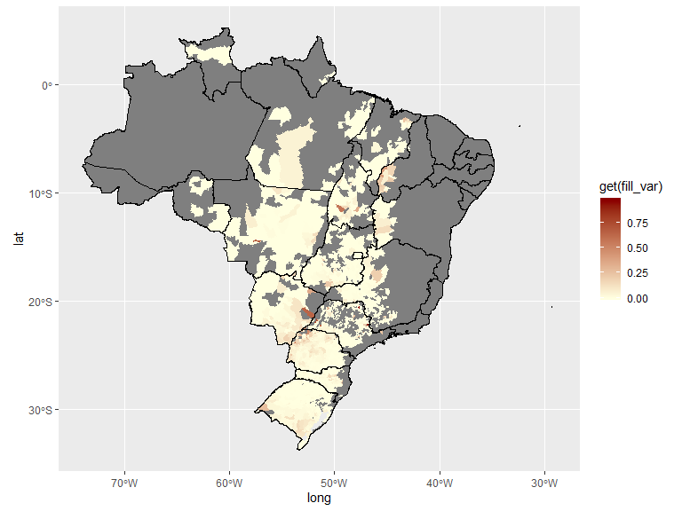

## Proagro

### Valor Enquadrado Médio

O valor enquadrado médio é mais alto no Proagro Tradicional do que no Proagro Mais, porém quando olhamos o valor enquadrado/área o valor do PRONAF é bem maior.

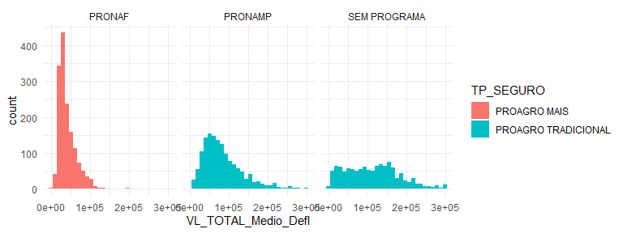

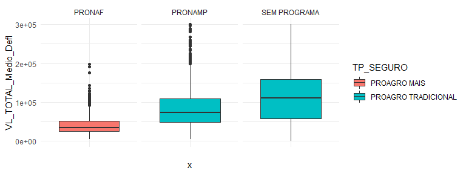

### Estatística descritiva

**VL_TOTAL_Medio_Defl por PROGRAMA**  
**Data Frame:** Proagro_soja_mun  
**N:** 1533

|  | PRONAF | PRONAMP | SEM PROGRAMA |
| --- | --- | --- | --- |
| **Média** | 41765.97 | 84950.76 | 113925.59 |
| **Desv.padrão** | 22902.61 | 51086.72 | 68168.98 |
| **Mín** | 4539.75 | 4991.66 | 101.50 |
| **Q1** | 25827.19 | 48893.21 | 57275.36 |
| **Med** | 34615.00 | 73629.57 | 111577.83 |
| **Q3** | 52356.41 | 108998.79 | 158536.36 |
| **Máx** | 197029.91 | 300000.00 | 300000.00 |
| **MDA** | 16416.83 | 41758.97 | 74222.94 |
| **IQE** | 26529.22 | 60070.53 | 101133.92 |

### Valor Enquadrado por Área

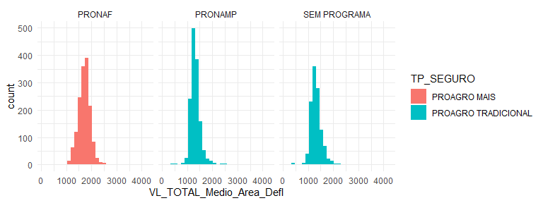

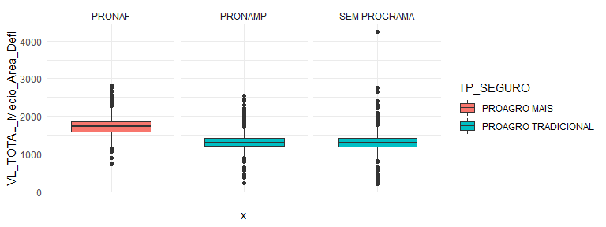

### Estatística descritiva  
**VL_TOTAL_Medio_Area_Defl por PROGRAMA**  
**Data Frame:** Proagro_soja_mun  
**N:** 1533

|  | PRONAF | PRONAMP | SEM PROGRAMA |
| --- | --- | --- | --- |
| **Média** | 1719.22 | 1324.67 | 1324.44 |
| **Desv.padrão** | 235.24 | 202.23 | 246.37 |
| **Mín** | 760.67 | 235.28 | 201.17 |
| **Q1** | 1577.23 | 1208.29 | 1187.79 |
| **Med** | 1727.80 | 1303.47 | 1300.58 |
| **Q3** | 1859.88 | 1412.43 | 1424.58 |
| **Máx** | 2816.34 | 2559.61 | 4239.68 |
| **MDA** | 211.41 | 151.39 | 178.53 |
| **IQE** | 282.65 | 203.84 | 236.70 |

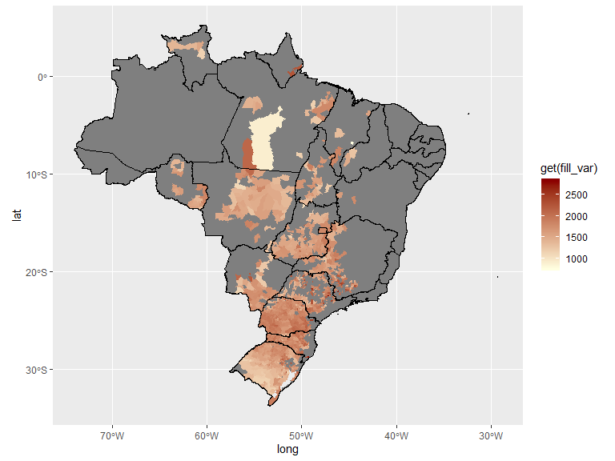

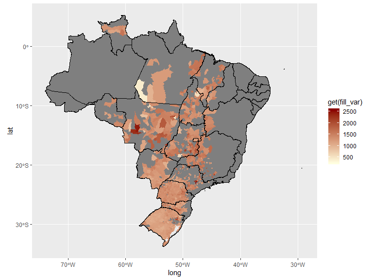

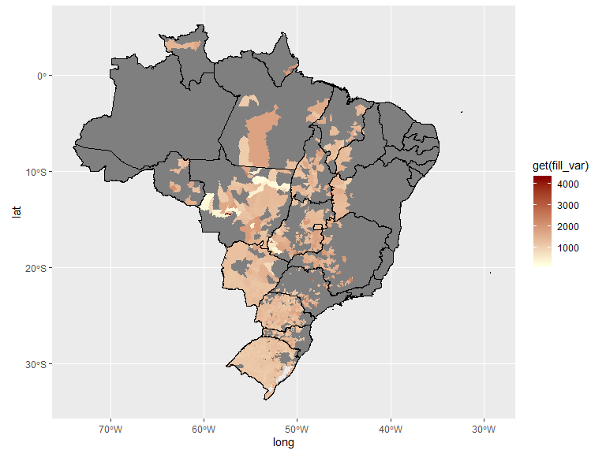

### Prêmio Médio

O Prêmio médio do Proagro Mais é bem concentrado e bem abaixo do Proagro Tradicional, porém o Prêmio/Área é bem parecido.

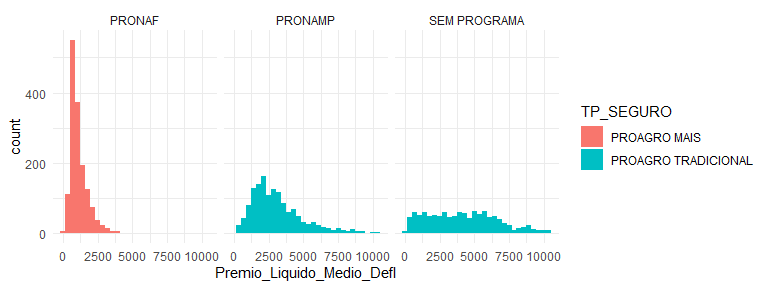

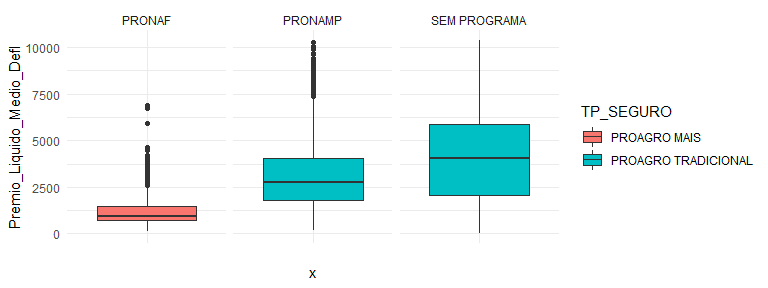

### Estatística descritiva

**Premio_Liquido_Medio_Defl por PROGRAMA**  
**Data Frame:** Proagro_soja_mun  
**N:** 1533

|  | PRONAF | PRONAMP | SEM PROGRAMA |
| --- | --- | --- | --- |
| **Média** | 1168.15 | 3161.71 | 4164.96 |
| **Desv.padrão** | 692.23 | 1909.63 | 2484.50 |
| **Mín** | 107.29 | 187.19 | 4.06 |
| **Q1** | 711.60 | 1807.61 | 2065.70 |
| **Med** | 958.59 | 2744.88 | 4046.34 |
| **Q3** | 1444.13 | 4035.20 | 5896.19 |
| **Máx** | 6896.05 | 10284.42 | 10373.08 |
| **MDA** | 460.04 | 1541.33 | 2859.99 |
| **IQE** | 732.53 | 2214.66 | 3828.25 |

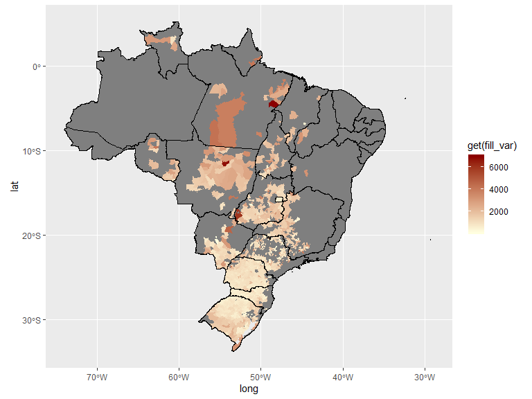

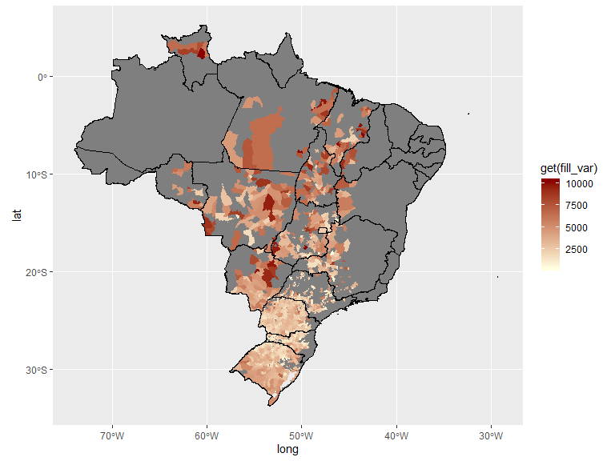

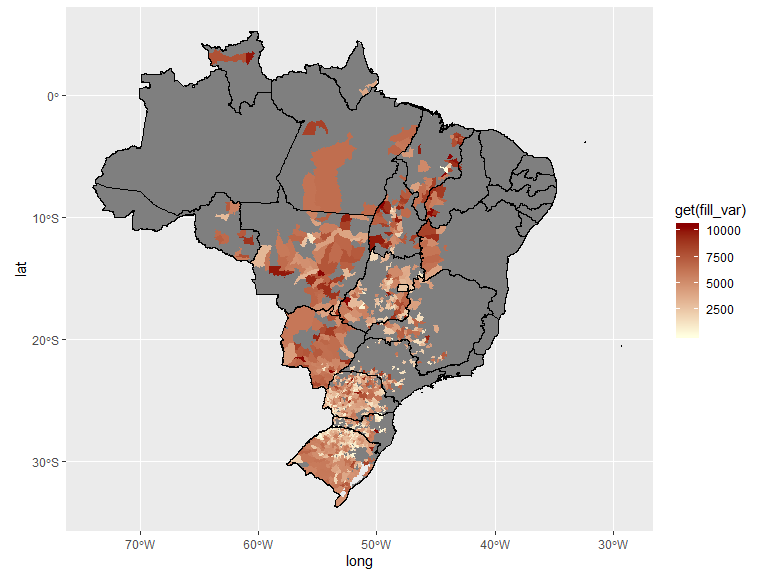

### Prêmio Médio por Área

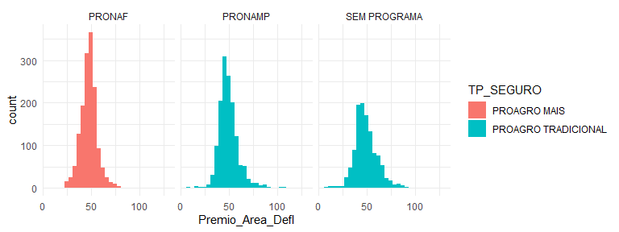

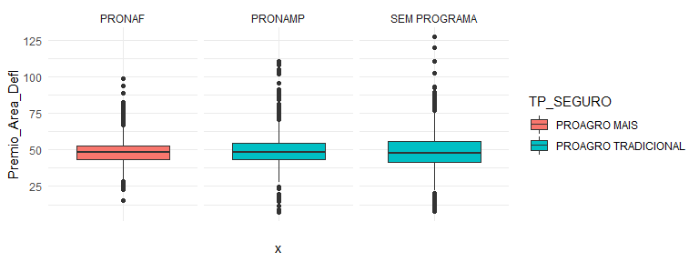

### Estatística descritiva

**Premio_Area_Defl por PROGRAMA**  
**Data Frame:** Proagro_soja_mun  
**N:** 1533

|  | PRONAF | PRONAMP | SEM PROGRAMA |
| --- | --- | --- | --- |
| **Média** | 47.91 | 49.81 | 49.26 |
| **Desv.padrão** | 8.63 | 10.71 | 12.43 |
| **Mín** | 15.21 | 7.06 | 7.90 |
| **Q1** | 43.07 | 43.55 | 41.59 |
| **Med** | 48.04 | 48.35 | 47.71 |
| **Q3** | 52.48 | 54.51 | 55.50 |
| **Máx** | 98.57 | 110.34 | 127.19 |
| **MDA** | 6.97 | 7.94 | 9.91 |
| **IQE** | 9.41 | 10.95 | 13.89 |

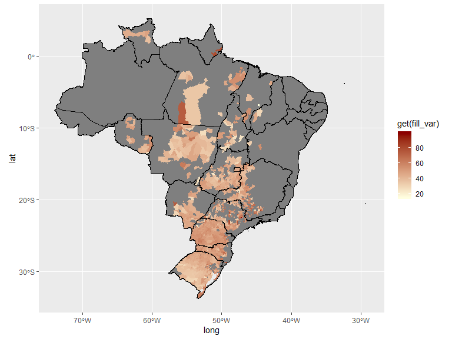

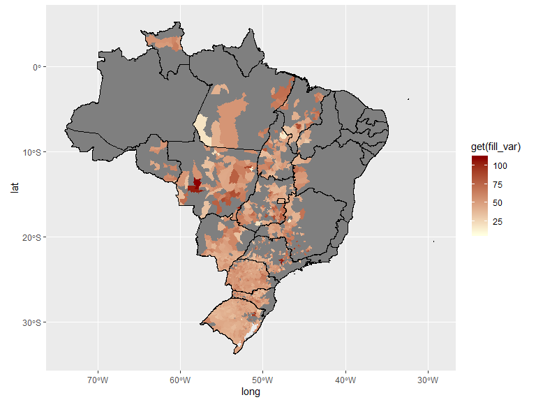

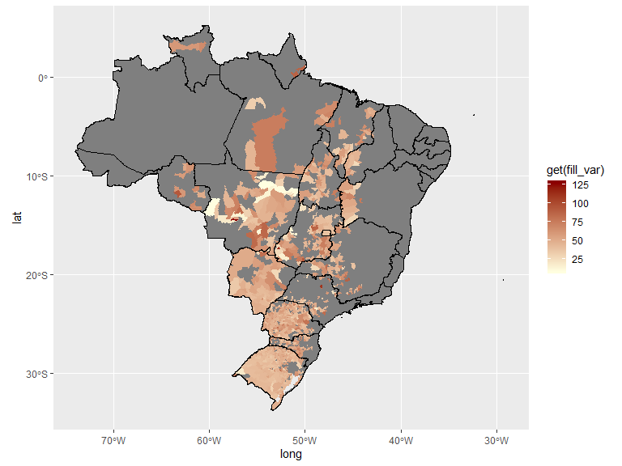

### Índice de Incidência Global (Qtd Sinistros/Qtd Total)

Apesar do número de municípios com sinistros do Proagro MAis ter sido bem superior aos demais, os Índices de Incidência são bem parecidos, uma vez que o % de seguros com sinistros são bem próximos.

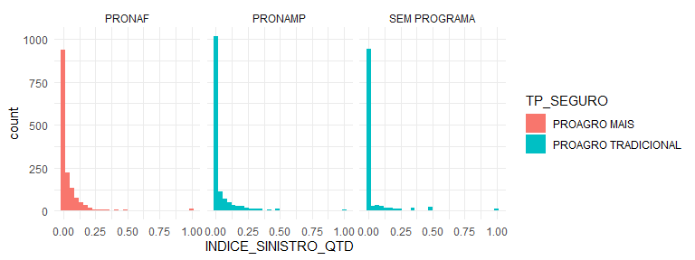

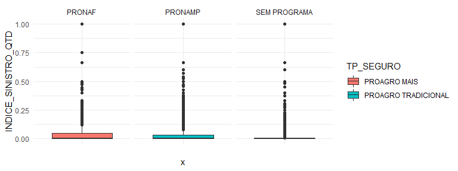

### Estatística descritiva

**INDICE_SINISTRO_QTD por PROGRAMA**  
**Data Frame:** Proagro_soja_mun  
**N:** 1533

|  | PRONAF | PRONAMP | SEM PROGRAMA |
| --- | --- | --- | --- |
| **Média** | 0.05 | 0.05 | 0.05 |
| **Desv.padrão** | 0.11 | 0.12 | 0.14 |
| **Mín** | 0.00 | 0.00 | 0.00 |
| **Q1** | 0.00 | 0.00 | 0.00 |
| **Med** | 0.00 | 0.00 | 0.00 |
| **Q3** | 0.05 | 0.03 | 0.00 |
| **Máx** | 1.00 | 1.00 | 1.00 |
| **MDA** | 0.01 | 0.00 | 0.00 |
| **IQE** | 0.05 | 0.03 | 0.00 |

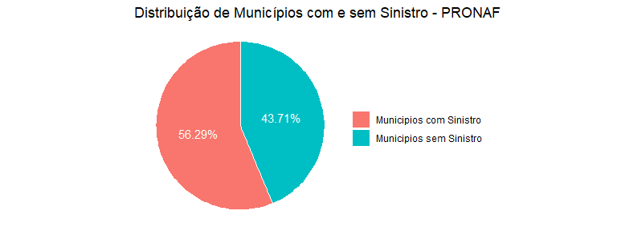

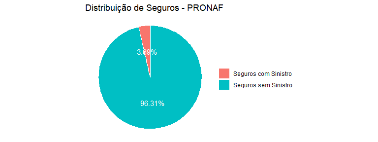

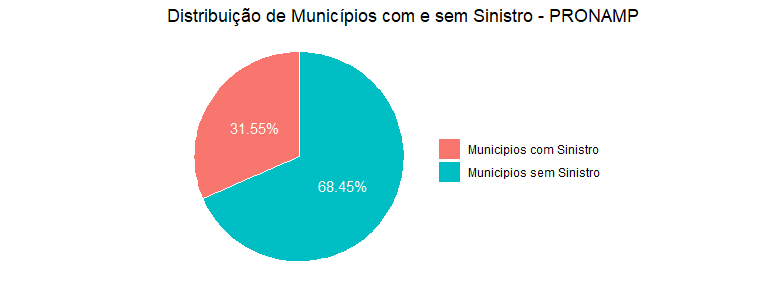

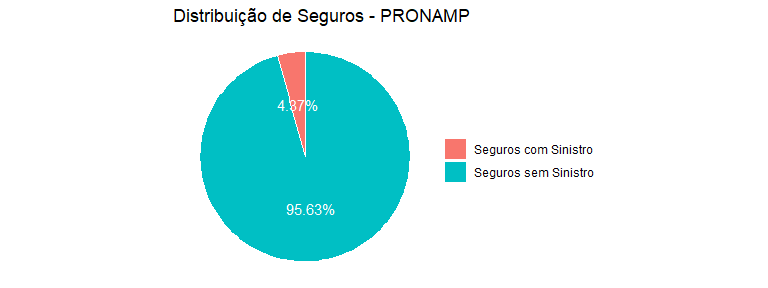

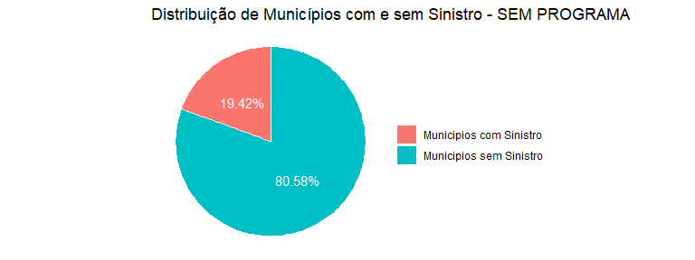

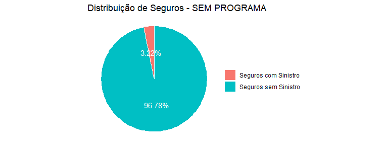

Retirando os zeros.

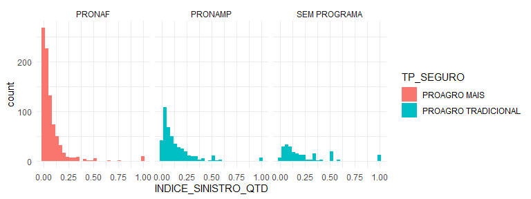

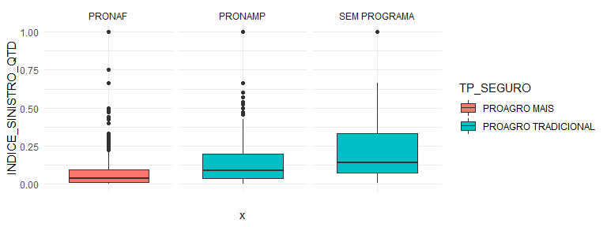

### Estatística descritiva  
**INDICE_SINISTRO_QTD por PROGRAMA**  
**Data Frame:** Proagro_soja_mun  
**N:** 863

|  | PRONAF | PRONAMP | SEM PROGRAMA |
| --- | --- | --- | --- |
| **Média** | 0.08 | 0.15 | 0.23 |
| **Desv.padrão** | 0.14 | 0.17 | 0.24 |
| **Mín** | 0.00 | 0.00 | 0.01 |
| **Q1** | 0.01 | 0.04 | 0.08 |
| **Med** | 0.04 | 0.09 | 0.14 |
| **Q3** | 0.09 | 0.20 | 0.33 |
| **Máx** | 1.00 | 1.00 | 1.00 |
| **MDA** | 0.05 | 0.09 | 0.13 |
| **IQE** | 0.08 | 0.16 | 0.26 |

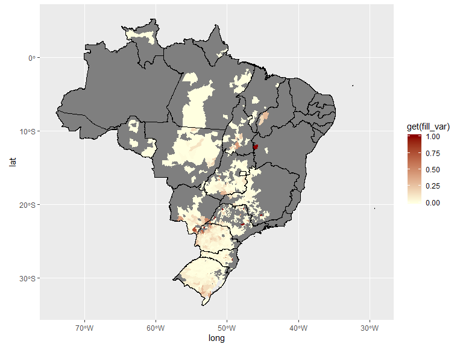

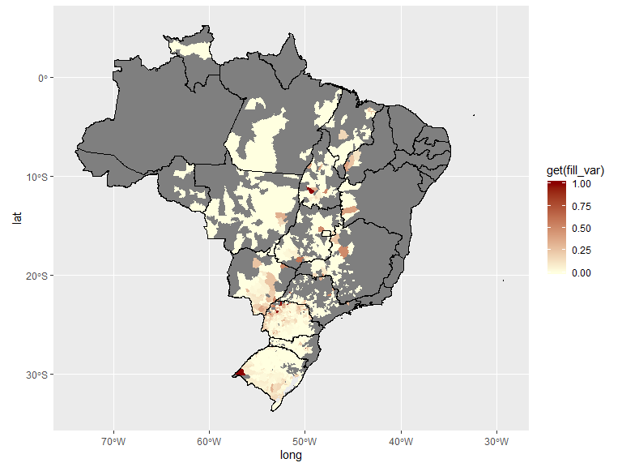

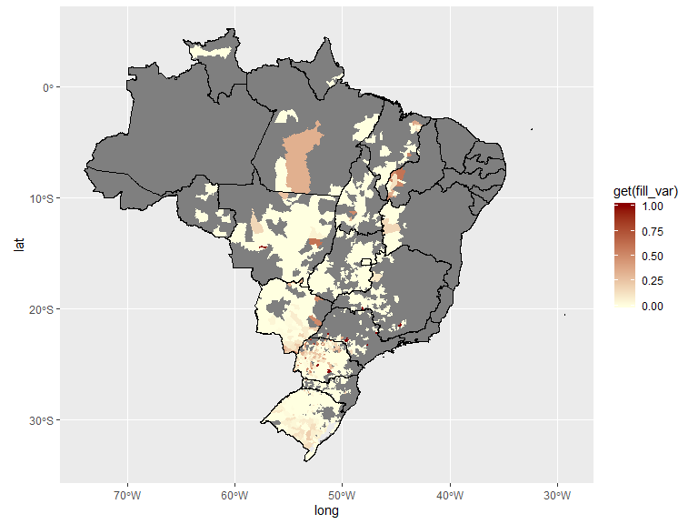

### Sinistro Médio

O sinistro médio do Proagro Mais é menor, porém não temos como comparar sem saber a área afetada. O ideal seria que tivéssemos a área que sofreu sinistro de cada município para compararmos Sinistro/Área.

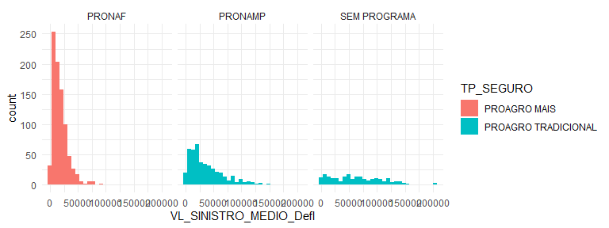

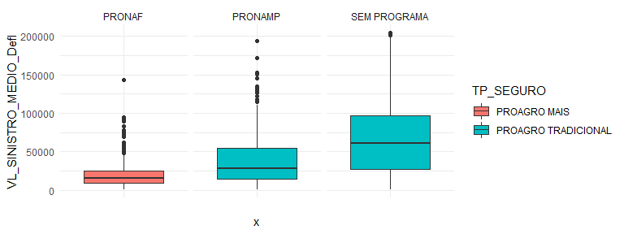

### Estatística descritiva  
**VL_SINISTRO_MEDIO_Defl por PROGRAMA**  
**Data Frame:** Proagro_soja_mun  
**N:** 1533

|  | PRONAF | PRONAMP | SEM PROGRAMA |
| --- | --- | --- | --- |
| **Média** | 18864.36 | 37972.12 | 65160.55 |
| **Desv.padrão** | 14504.98 | 32252.81 | 45874.03 |
| **Mín** | 404.93 | 253.53 | 557.72 |
| **Q1** | 8919.70 | 14224.72 | 26760.02 |
| **Med** | 15286.94 | 27931.07 | 60805.43 |
| **Q3** | 24725.94 | 54262.49 | 96809.41 |
| **Máx** | 143178.12 | 194461.77 | 204476.52 |
| **MDA** | 10671.85 | 25725.85 | 52772.85 |
| **IQE** | 15670.89 | 40037.77 | 69857.39 |

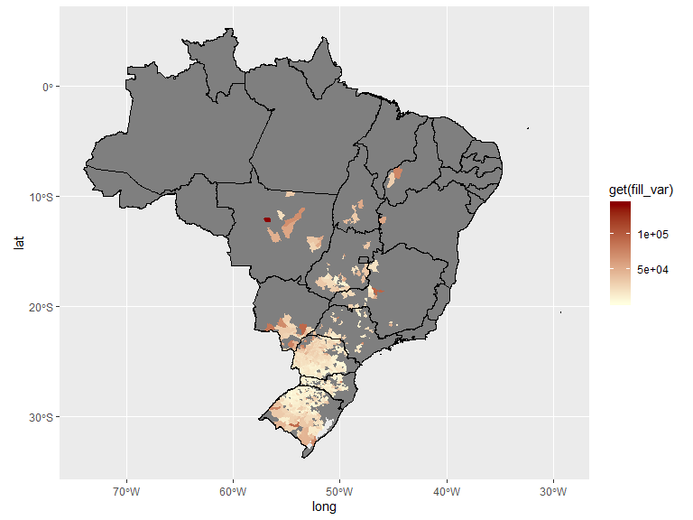

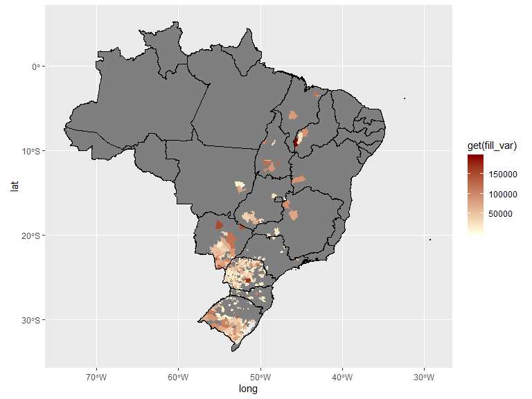

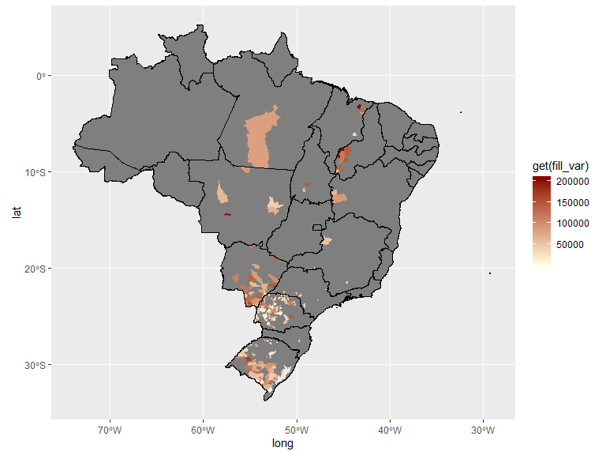

### Índice de Sinistralidade

O índice de sinistralidade dos prorgamas possuem médias parecidas, porém temos um comportamento interessante. O Proagro Tradicional possui uma quantidade maior de índices zerados, porém, quando os valores ocorrem, tendem a ser maiores que o Proagro Mais.

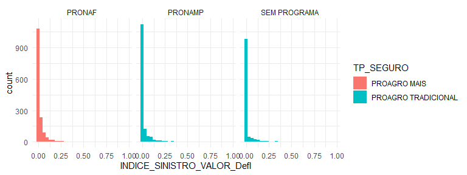

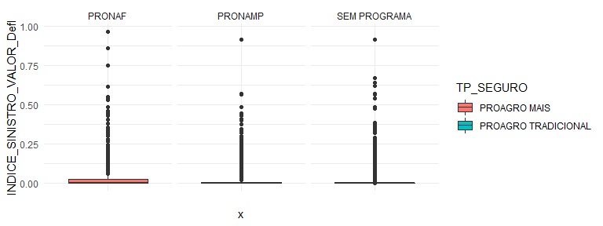

### Estatística descritiva  
**INDICE_SINISTRO_VALOR_Defl por PROGRAMA**  
**Data Frame:** Proagro_soja_mun  
**N:** 1533

|  | PRONAF | PRONAMP | SEM PROGRAMA |
| --- | --- | --- | --- |
| **Média** | 0.03 | 0.02 | 0.02 |
| **Desv.padrão** | 0.07 | 0.06 | 0.08 |
| **Mín** | 0.00 | 0.00 | 0.00 |
| **Med** | 0.00 | 0.00 | 0.00 |
| **Máx** | 0.97 | 0.92 | 0.92 |

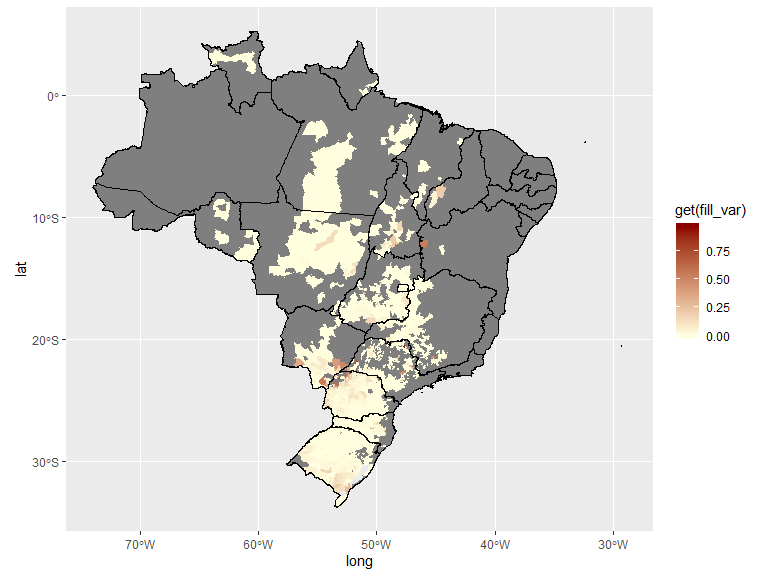

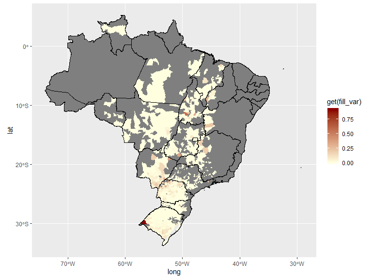

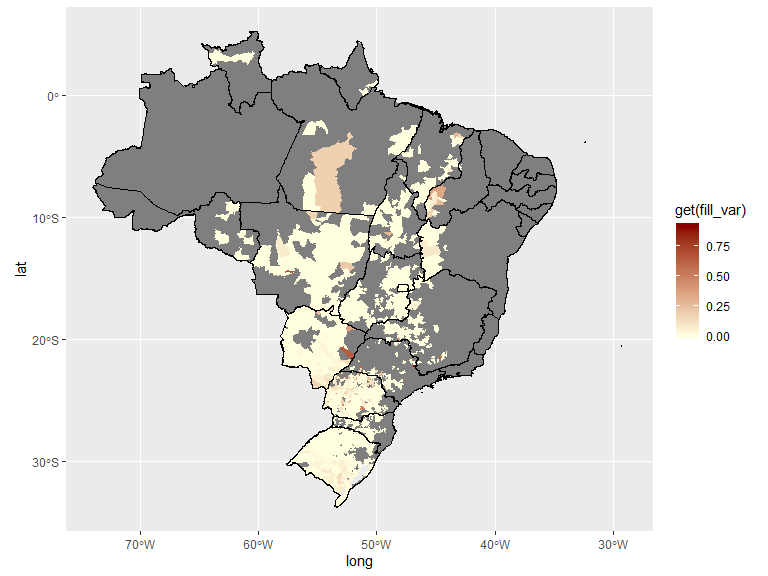

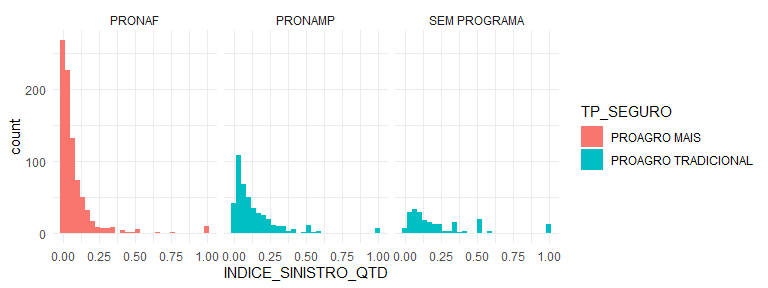

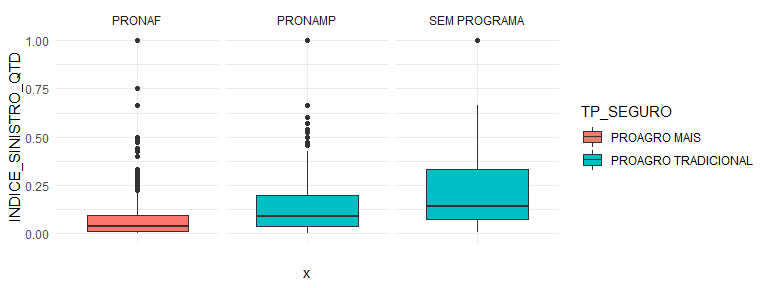

|  | PRONAF | PRONAMP | SEM PROGRAMA |
| --- | --- | --- | --- |
| **Média** | 0.08 | 0.15 | 0.23 |
| **Desv.padrão** | 0.14 | 0.17 | 0.24 |
| **Mín** | 0.00 | 0.00 | 0.01 |
| **Med** | 0.04 | 0.09 | 0.14 |
| **Máx** | 1.00 | 1.00 | 1.00 |